# Predicting Efficient Barbell Lifts

Joe Yadush

October 12, 2017

## Executive Summary

This excercise will use R and some basic machine learning algorithms to predict how well barbell lifts were accomplished from a set of 20 test records. The data is grouped into 5 classifications with the ‘A’ class being the group of roll, pitch, and yaw measurements from wearable recording devices that define a correct executement of the excercise. For more information on the classifications, data, and collection methods please refer to the Human Actvity Recognition paper which was the source for this assignment.

**Paper citation:** Velloso, E.; Bulling, A.; Gellersen, H.; Ugulino, W.; Fuks, H. Qualitative Activity Recognition of Weight Lifting Exercises. Proceedings of 4th International Conference in Cooperation with SIGCHI (Augmented Human ’13) . Stuttgart, Germany: ACM SIGCHI, 2013.

## Getting and Cleaning the Data

We will download the data from the aforementioned site

```r
library(randomForest)
library(caret)
library(rattle)
library(gbm)
```

```r
knitr::opts_chunk$set(echo = TRUE)

if (!file.exists("pml-training.csv")) {
        download.file("https://d396qusza40orc.cloudfront.net/predmachlearn/pml-training.csv", "pml-training.csv")
}
if (!file.exists("pml-testing.csv")) {
        download.file("https://d396qusza40orc.cloudfront.net/predmachlearn/pml-testing.csv", "pml-testing.csv")
}
```

Using R, read the data into data frames, identifying missing data

```r
df_training_data <- read.csv("pml-training.csv", header=TRUE, na.strings=c("NA", "#DIV/0!", ""))
df_testing_data <- read.csv("pml-testing.csv", header=TRUE, na.strings=c("NA", "#DIV/0!", ""))
```

```r
df_training_data <- df_training_data[, colSums(is.na(df_training_data)) == 0]
df_testing_data  <- df_testing_data[, colSums(is.na(df_testing_data)) == 0]
```

Now we will remove the first seven columns that are essentially row identifiers with no relevance

```r
df_training_data <- df_training_data[, -c(1:7)]
df_testing_data  <- df_testing_data[, -c(1:7)]
```

Examine data for any zero covariates

```r
nsv <- nearZeroVar(df_training_data, saveMetrics = TRUE)
nsv <- nearZeroVar(df_testing_data, saveMetrics = TRUE)
```

For **cross-validation** approach we will split the training set into a train and test while leaving original test set untouched for unbiased measurement

```r
inTrain <- createDataPartition(df_training_data$classe, p = 0.7, list = FALSE)
train <- df_training_data[inTrain, ]
test  <- df_training_data[-inTrain, ]
```

## Model Selection

Attempting three different models to examine for accuracy learned from the course. Decision Tree (Dendograms), Random Forests, and Boosting

Dendogram

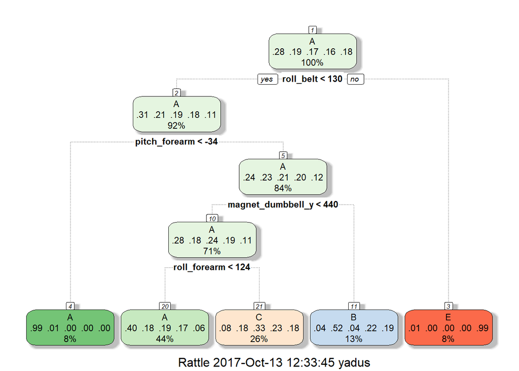

```r
set.seed(9798)
treeFit <- train(classe ~., method = "rpart", data = train)
fancyRpartPlot(treeFit$finalModel)
```

```r
predictTree <- predict(treeFit, test)
matrixTree <- confusionMatrix(predictTree, test$classe)
matrixTree
```

```
## Confusion Matrix and Statistics
##
##           Reference
## Prediction    A    B    C    D    E
##          A 1527  494  464  430  149
##          B   17  373   34  186  148
##          C  125  272  528  348  295
##          D    0    0    0    0    0
##          E    5    0    0    0  490
##
## Overall Statistics
##
##                Accuracy : 0.4958
##                  95% CI : (0.483, 0.5087)
##     No Information Rate : 0.2845
##     P-Value [Acc > NIR] : < 2.2e-16
##
##                   Kappa : 0.341
##  Mcnemar's Test P-Value : NA
##
## Statistics by Class:
##
##                      Class: A Class: B Class: C Class: D Class: E
## Sensitivity            0.9122  0.32748  0.51462   0.0000  0.45287
## Specificity            0.6350  0.91888  0.78596   1.0000  0.99896
## Pos Pred Value         0.4984  0.49208  0.33673      NaN  0.98990
## Neg Pred Value         0.9479  0.85059  0.88464   0.8362  0.89017
## Prevalence             0.2845  0.19354  0.17434   0.1638  0.18386
## Detection Rate         0.2595  0.06338  0.08972   0.0000  0.08326
## Detection Prevalence   0.5206  0.12880  0.26644   0.0000  0.08411
## Balanced Accuracy      0.7736  0.62318  0.65029   0.5000  0.72591
```

Random Forest

```r
set.seed(9798)
##forestFit <- train(classe ~., data = train, method = "rf", prox = TRUE)
forestFit <- randomForest(classe~., data = train)
predictForest <- predict(forestFit, test)
matrixForest <- confusionMatrix(predictForest, test$classe)
matrixForest
```

```
## Confusion Matrix and Statistics
##
##           Reference
## Prediction    A    B    C    D    E
##          A 1674    5    0    0    0
##          B    0 1134    5    0    0
##          C    0    0 1021   10    0
##          D    0    0    0  953    2
##          E    0    0    0    1 1080
##
## Overall Statistics
##
##                Accuracy : 0.9961
##                  95% CI : (0.9941, 0.9975)
##     No Information Rate : 0.2845
##     P-Value [Acc > NIR] : < 2.2e-16
##
##                   Kappa : 0.9951
##  Mcnemar's Test P-Value : NA
##
## Statistics by Class:
##
##                      Class: A Class: B Class: C Class: D Class: E
## Sensitivity            1.0000   0.9956   0.9951   0.9886   0.9982
## Specificity            0.9988   0.9989   0.9979   0.9996   0.9998
## Pos Pred Value         0.9970   0.9956   0.9903   0.9979   0.9991
## Neg Pred Value         1.0000   0.9989   0.9990   0.9978   0.9996
## Prevalence             0.2845   0.1935   0.1743   0.1638   0.1839
## Detection Rate         0.2845   0.1927   0.1735   0.1619   0.1835
## Detection Prevalence   0.2853   0.1935   0.1752   0.1623   0.1837
## Balanced Accuracy      0.9994   0.9973   0.9965   0.9941   0.9990
```

Boosting with Regression Trees

```r
set.seed(9798)
gbmFit <- train(classe ~., data = train, method = "gbm", verbose = FALSE)
gbmPredict <- predict(gbmFit, newdata = test)
gbmMatrix <- confusionMatrix(gbmPredict, test$classe)
gbmMatrix
```

```
## Confusion Matrix and Statistics
##
##           Reference
## Prediction    A    B    C    D    E
##          A 1649   29    0    0    1
##          B   16 1080   32    2   14
##          C    6   27  981   38    5
##          D    3    2   12  919   12
##          E    0    1    1    5 1050
##
## Overall Statistics
##
##                Accuracy : 0.965
##                  95% CI : (0.96, 0.9695)
##     No Information Rate : 0.2845
##     P-Value [Acc > NIR] : < 2.2e-16
##
##                   Kappa : 0.9557
##  Mcnemar's Test P-Value : 2.66e-06
##
## Statistics by Class:
##
##                      Class: A Class: B Class: C Class: D Class: E
## Sensitivity            0.9851   0.9482   0.9561   0.9533   0.9704
## Specificity            0.9929   0.9865   0.9844   0.9941   0.9985
## Pos Pred Value         0.9821   0.9441   0.9281   0.9694   0.9934
## Neg Pred Value         0.9941   0.9876   0.9907   0.9909   0.9934
## Prevalence             0.2845   0.1935   0.1743   0.1638   0.1839
## Detection Rate         0.2802   0.1835   0.1667   0.1562   0.1784
## Detection Prevalence   0.2853   0.1944   0.1796   0.1611   0.1796
## Balanced Accuracy      0.9890   0.9674   0.9702   0.9737   0.9845
```

## Conclusion and Prediction Results

The results applied against the Random Forest are shown below:

```r
finalPrediction <- predict(forestFit, df_testing_data)
finalPrediction
```

```
##  1  2  3  4  5  6  7  8  9 10 11 12 13 14 15 16 17 18 19 20
##  B  A  B  A  A  E  D  B  A  A  B  C  B  A  E  E  A  B  B  B
## Levels: A B C D E
```